# Exam 1

## Exam 1

#### Question

1. La gráfica muestra información de las poblaciones de 5 países desde 1950 hasta 2000.

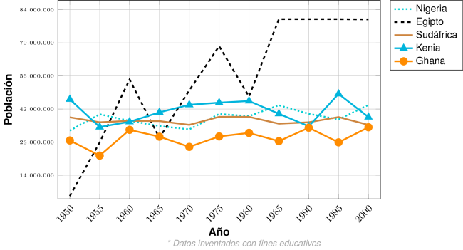

   Los datos representan la evolución demográfica de diferentes naciones a lo largo de varias décadas, mostrando distintas tendencias de crecimiento poblacional.

   Aproximadamente, ¿en qué año las poblaciones de **Nigeria** y **Sudáfrica** fueron iguales?
   1. 1960
   2. 1965
   3. 1950
   4. 2000

#### Solution

   Para resolver este problema, debemos identificar el punto donde las líneas de **Nigeria** y **Sudáfrica** se intersectan en la gráfica.

   **Análisis visual de las tendencias:**
   - **Nigeria**: Inicia con una población menor pero presenta un crecimiento más acelerado.
   - **Sudáfrica**: Comienza con una población mayor pero su crecimiento es más moderado.

   **Identificación del punto de intersección:**

   Observando cuidadosamente la gráfica, las dos líneas se cruzan aproximadamente en el año **1960**, donde ambas poblaciones alcanzan un valor similar de aproximadamente 37.000.000 habitantes.